# Checking Voice Data

Kendra Wyant

2020-08-12

### Notes

This script checks data from RISK participants’ voice calls by computing descriptives and checking for missingness and potential errors.

Thoughts for discussion:  
1. How do we want to handle spam/irrelevant calls for analyses?  
2. What does a call with contact_type self mean?  
3. Differences between call_type rejected vs. refused?  
4. Is there a way to identify calls with study staff? It is possible they may be contributing to the large number of calls with no contact_type identified.

### Setup

Paths

```r
path_data <- "./analysis/shared/data"
```

Packages

```r
library(tidyverse)
library(janitor)
library(lubridate)
library(kableExtra)
```

### Import Data and glimpse

Voice data

```r
voice <- read_rds(file.path(path_data, "ds_voice.rds"))
voice <- voice %>%
  mutate(time_central = as_datetime(utc, tz = 'America/Chicago')) %>%
  mutate(date_central = date(time_central),
         hour_central = hour(time_central),
         minute_central = minute(time_central),
         second_central = second(time_central)) %>%
  select(-c(utc, time_central)) %>%
  glimpse()
```

```
## Rows: 66,383
## Columns: 15
## $ subid          <dbl> 1, 1, 1, 1, 1, 1, 1, 1, 1, 1, 1, 1, 1, 1, 1, 1, 1…
## $ phone          <dbl> 6085091830, 6088904796, 6084385017, 6082131910, 6…
## $ duration       <dbl> 44, 19, 41, 0, 61, 41, 0, 0, 0, 0, 0, 13, 62, 54,…
## $ type           <dbl> 2, 2, 2, 2, 1, 1, 1, 1, 1, 1, 1, 1, 2, 2, 2, 2, 1…
## $ contact_type   <chr> "OTHER", NA, "FRIEND", "CO-WORKER/BUSINESS CONTAC…
## $ drank_past     <chr> "NEVER/ALMOST NEVER", NA, "NEVER/ALMOST NEVER", "…
## $ drinker_status <chr> "NONDRINKER", NA, "NONDRINKER", "DONT KNOW", NA, …
## $ drink_future   <chr> "NO", NA, "NO", "NO", NA, NA, NA, NA, NA, NA, NA,…
## $ recovery       <chr> "DONT KNOW", NA, "DONT KNOW", "YES", NA, NA, NA, …
## $ support        <chr> "SUPPORTIVE", NA, "SUPPORTIVE", "SUPPORTIVE", NA,…
## $ emotion        <chr> "PLEASANT", NA, "PLEASANT", "PLEASANT", NA, NA, N…
## $ date_central   <date> 2017-04-30, 2017-05-01, 2017-05-01, 2017-05-01, …
## $ hour_central   <int> 10, 9, 9, 9, 8, 11, 9, 9, 9, 9, 9, 9, 9, 13, 9, 1…
## $ minute_central <int> 33, 7, 13, 28, 36, 19, 2, 3, 5, 8, 17, 21, 26, 49…
## $ second_central <dbl> 35.200000, 59.000000, 26.500000, 17.400000, 11.41…
```

154 participants contribute to a total of 66383 voice call observations. The earliest recorded sms message is from 2017-03-22 and the last is from 2019-12-04.

Missing values

```r
if(any(is.na(voice))){
  missing <- voice %>%
    summarise(across(everything(), ~sum(is.na(.)))) %>%
    gather(key = "var", value = "num_NA" ) %>%
    filter(num_NA > 0)
  missing %>%
    kable(caption = "Variables with missing values", table.attr = "style='width:40%;'") %>%
    kable_styling(position = "left", bootstrap_options = "condensed")
}else {
  paste("No missing values")
}
```

Variables with missing values

| var | num_NA |
| --- | --- |
| contact_type | 15508 |
| drank_past | 26241 |
| drinker_status | 26218 |
| drink_future | 26220 |
| recovery | 26268 |
| support | 26223 |
| emotion | 26243 |

There are 172921 missing values (NA) from 7 unique variables in the entire dataset.

Closer look at missing values

```r
voice %>%
  filter(is.na(contact_type)) %>%
  select(-c(date_central:second_central)) %>%
  head(n = 30) %>%
  kable(caption = "Sample observations with missing contact type") %>%
  kable_styling(bootstrap_options = "condensed")
```

Sample observations with missing contact type

| subid | phone | duration | type | contact_type | drank_past | drinker_status | drink_future | recovery | support | emotion |
| --- | --- | --- | --- | --- | --- | --- | --- | --- | --- | --- |
| 1 | 6088904796 | 19 | 2 | NA | NA | NA | NA | NA | NA | NA |
| 1 | 6085201499 | 61 | 1 | NA | NA | NA | NA | NA | NA | NA |
| 1 | 6085201499 | 41 | 1 | NA | NA | NA | NA | NA | NA | NA |
| 1 | 6085201499 | 0 | 1 | NA | NA | NA | NA | NA | NA | NA |
| 1 | 6085201499 | 0 | 1 | NA | NA | NA | NA | NA | NA | NA |
| 1 | 6085201499 | 0 | 1 | NA | NA | NA | NA | NA | NA | NA |
| 1 | 6085201499 | 0 | 1 | NA | NA | NA | NA | NA | NA | NA |
| 1 | 6085201499 | 0 | 1 | NA | NA | NA | NA | NA | NA | NA |
| 1 | 6085201499 | 13 | 1 | NA | NA | NA | NA | NA | NA | NA |
| 1 | 8152890515 | 62 | 2 | NA | NA | NA | NA | NA | NA | NA |
| 1 | 8152890515 | 54 | 2 | NA | NA | NA | NA | NA | NA | NA |
| 1 | 8152890515 | 37 | 2 | NA | NA | NA | NA | NA | NA | NA |
| 1 | 6088904796 | 0 | 1 | NA | NA | NA | NA | NA | NA | NA |
| 1 | 6085088742 | 0 | 2 | NA | NA | NA | NA | NA | NA | NA |
| 1 | 6083206523 | 0 | 1 | NA | NA | NA | NA | NA | NA | NA |
| 1 | 8152890515 | 64 | 2 | NA | NA | NA | NA | NA | NA | NA |
| 1 | 8152890515 | 115 | 2 | NA | NA | NA | NA | NA | NA | NA |
| 1 | 6086979528 | 0 | 2 | NA | NA | NA | NA | NA | NA | NA |
| 1 | 6086979528 | 5 | 1 | NA | NA | NA | NA | NA | NA | NA |
| 1 | 6085201499 | 40 | 2 | NA | NA | NA | NA | NA | NA | NA |
| 1 | 8152890515 | 21 | 2 | NA | NA | NA | NA | NA | NA | NA |
| 1 | 6085201499 | 11 | 2 | NA | NA | NA | NA | NA | NA | NA |
| 1 | 6085201499 | 7 | 2 | NA | NA | NA | NA | NA | NA | NA |
| 1 | 6085201499 | 25 | 2 | NA | NA | NA | NA | NA | NA | NA |
| 1 | 6084435480 | 0 | 1 | NA | NA | NA | NA | NA | NA | NA |
| 1 | 6083206523 | 0 | 1 | NA | NA | NA | NA | NA | NA | NA |
| 1 | 6085201499 | 0 | 2 | NA | NA | NA | NA | NA | NA | NA |
| 1 | 6084435480 | 189 | 2 | NA | NA | NA | NA | NA | NA | NA |
| 1 | 6085201499 | 17 | 2 | NA | NA | NA | NA | NA | NA | NA |
| 1 | 6085201499 | 0 | 2 | NA | NA | NA | NA | NA | NA | NA |

```r
missing_contacttype <- voice %>%
  filter(is.na(contact_type)) %>%
  group_by(subid) %>%
  summarise(n_NA = n())

missing_contacttype %>%
  head(n = 20) %>%
  kable(caption = "Table head of number of missing contact_type values per subid",
        table.attr = "style='width:40%;'") %>%
  kable_styling(position = "left", bootstrap_options = "condensed")
```

Table head of number of missing contact_type values per subid

| subid | n_NA |
| --- | --- |
| 1 | 35 |
| 2 | 293 |
| 3 | 298 |
| 5 | 417 |
| 6 | 82 |
| 7 | 108 |
| 9 | 109 |
| 10 | 101 |
| 11 | 52 |
| 15 | 70 |
| 16 | 81 |
| 18 | 100 |
| 19 | 64 |
| 20 | 149 |
| 21 | 39 |
| 23 | 39 |
| 25 | 102 |
| 26 | 20 |
| 27 | 95 |
| 28 | 171 |

153 participants have voice call observations with missing contact type values. Participants on average have 101.36 missing contact type values each.

COMMENT KW 2020-08-11: Do we have study calls to participants regularly? I see a lot of repeated numbers within contact_type NA.

Spam/irrelevant calls

```r
spam <- voice %>%
  filter(contact_type == "IRRELEVANT/SPAM") %>%
  select(-c(date_central:second_central))

spam_NA <- spam %>%
  filter(across(c(drank_past:emotion), ~is.na(.)))

spam %>%
  head(n = 20) %>%
  kable(caption = "Sample from spam subset",
          table.attr = "style='width:40%;'") %>%
  kable_styling(position = "left", bootstrap_options = "condensed")
```

Sample from spam subset

| subid | phone | duration | type | contact_type | drank_past | drinker_status | drink_future | recovery | support | emotion |
| --- | --- | --- | --- | --- | --- | --- | --- | --- | --- | --- |
| 6 | 4147717900 | 715 | 2 | IRRELEVANT/SPAM | NA | NA | NA | NA | NA | NA |
| 6 | 4147717900 | 362 | 2 | IRRELEVANT/SPAM | NA | NA | NA | NA | NA | NA |
| 6 | 4147717900 | 148 | 1 | IRRELEVANT/SPAM | NA | NA | NA | NA | NA | NA |
| 6 | 4147717900 | 16 | 1 | IRRELEVANT/SPAM | NA | NA | NA | NA | NA | NA |
| 6 | 4147717900 | 161 | 2 | IRRELEVANT/SPAM | NA | NA | NA | NA | NA | NA |
| 6 | 6083345599 | 16 | 2 | IRRELEVANT/SPAM | NA | NA | NA | NA | NA | NA |
| 6 | 6083345599 | 3 | 2 | IRRELEVANT/SPAM | NA | NA | NA | NA | NA | NA |
| 6 | 6083345599 | 21 | 1 | IRRELEVANT/SPAM | NA | NA | NA | NA | NA | NA |
| 6 | 6083345599 | 13 | 1 | IRRELEVANT/SPAM | NA | NA | NA | NA | NA | NA |
| 6 | 6082510042 | 0 | 1 | IRRELEVANT/SPAM | NA | NA | NA | NA | NA | NA |
| 6 | 6082510042 | 6 | 1 | IRRELEVANT/SPAM | NA | NA | NA | NA | NA | NA |
| 6 | 6082510042 | 9 | 1 | IRRELEVANT/SPAM | NA | NA | NA | NA | NA | NA |
| 6 | 6082510042 | 0 | 1 | IRRELEVANT/SPAM | NA | NA | NA | NA | NA | NA |
| 6 | 8888422357 | 0 | 2 | IRRELEVANT/SPAM | NA | NA | NA | NA | NA | NA |
| 6 | 6082510042 | 107 | 2 | IRRELEVANT/SPAM | NA | NA | NA | NA | NA | NA |
| 6 | 6082510042 | 0 | 1 | IRRELEVANT/SPAM | NA | NA | NA | NA | NA | NA |
| 6 | 6082323171 | 86 | 2 | IRRELEVANT/SPAM | NA | NA | NA | NA | NA | NA |
| 6 | 6082510042 | 0 | 1 | IRRELEVANT/SPAM | NA | NA | NA | NA | NA | NA |
| 6 | 6082323171 | 150 | 2 | IRRELEVANT/SPAM | NA | NA | NA | NA | NA | NA |
| 6 | 6082323171 | 71 | 2 | IRRELEVANT/SPAM | NA | NA | NA | NA | NA | NA |

There are 9452 spam calls and 9452 of the spam calls are missing values for all context variables. Will create voice_withoutspam dataframe (below) to run all context analyses.

Spam/Irrelevant calls and missing values

```r
voice_withoutspam <- voice %>%
  filter(!contact_type == "IRRELEVANT/SPAM" | is.na(contact_type))

if(any(is.na(voice_withoutspam))){
  missing <- voice_withoutspam %>%
    summarise(across(everything(), ~sum(is.na(.)))) %>%
    gather(key = "var", value = "num_NA" ) %>%
    filter(num_NA > 0)
  missing %>%
    kable(caption = "Variables with missing values after spam calls removed",
          table.attr = "style='width:40%;'") %>%
    kable_styling(position = "left", bootstrap_options = "condensed")
}else {
  paste("No missing values")
}
```

Variables with missing values after spam calls removed

| var | num_NA |
| --- | --- |
| contact_type | 15508 |
| drank_past | 16789 |
| drinker_status | 16766 |
| drink_future | 16768 |
| recovery | 16816 |
| support | 16771 |
| emotion | 16791 |

Once irrelevant and spam calls are removed we now have a new total of 56931 voice calls and missing values decreased from 172921 to 116209.  
The majority of remaining missing values are then of contact type NA or self (see below).

```r
voice_withoutspam %>%
  mutate(contact_type = tolower(contact_type)) %>%
  group_by(contact_type) %>%
  summarise(across(drank_past:emotion, ~sum(is.na(.)))) %>%
    kable(caption = "Missing values by contact type after spam calls removed") %>%
    kable_styling()
```

Missing values by contact type after spam calls removed

| contact_type | drank_past | drinker_status | drink_future | recovery | support | emotion |
| --- | --- | --- | --- | --- | --- | --- |
| aunt/uncle | 0 | 0 | 0 | 0 | 0 | 0 |
| child | 0 | 0 | 0 | 0 | 0 | 0 |
| co-worker/business contact | 19 | 20 | 21 | 19 | 19 | 19 |
| counselor | 1 | 1 | 1 | 1 | 1 | 1 |
| cousin | 0 | 0 | 0 | 34 | 0 | 34 |
| family-other | 39 | 39 | 39 | 39 | 29 | 39 |
| friend | 30 | 6 | 7 | 23 | 22 | 6 |
| grandparent | 0 | 0 | 0 | 0 | 0 | 0 |
| other | 17 | 17 | 17 | 17 | 17 | 9 |
| parent | 0 | 0 | 0 | 0 | 0 | 0 |
| self | 1172 | 1172 | 1172 | 1172 | 1172 | 1172 |
| sibling | 0 | 0 | 0 | 0 | 0 | 0 |
| social worker/case manager | 4 | 4 | 4 | 4 | 4 | 4 |
| spouse/significant other | 0 | 0 | 0 | 0 | 0 | 0 |
| NA | 15507 | 15507 | 15507 | 15507 | 15507 | 15507 |

COMMENT KW 2020-08-11: What are calls with contact type self?

### Descriptives

#### Voice calls

Call type

```r
voice %>%
  tabyl(type, show_na = TRUE) %>%
  adorn_totals("row") %>%
  kable(caption = "Type of voice call") %>%
  kable_styling(full_width = FALSE, position = "left")
```

Type of voice call

| type | n | percent |
| --- | --- | --- |
| 1 | 23488 | 0.3538255 |
| 2 | 35279 | 0.5314463 |
| 3 | 6096 | 0.0918307 |
| 5 | 936 | 0.0141000 |
| 6 | 344 | 0.0051820 |
| 7 | 1 | 0.0000151 |
| 8 | 53 | 0.0007984 |
| 9 | 88 | 0.0013256 |
| 10 | 17 | 0.0002561 |
| 1000 | 2 | 0.0000301 |
| 1001 | 39 | 0.0005875 |
| 1002 | 40 | 0.0006026 |
| Total | 66383 | 1.0000000 |

COMMENT KW 2020-08-12: Not sure what these call types are. Numbers in codebook also seem off:  
1 = incoming, 2 = outgoing, 3 = draft, 5 = unknown/undefined, 19 = unknown/undefined, -1 = unknown/undefined.  
Code block below inspects these types –> see comment after code block for resolution.

```r
# type 3 - call duration = 0
voice %>%
  filter(type == 3) %>%
  select(subid, duration, contact_type) %>%
  head(n = 15) %>%
  kable(caption = "Sample from type 3") %>%
  kable_styling(full_width = FALSE, position = "left")
```

Sample from type 3

| subid | duration | contact_type |
| --- | --- | --- |
| 2 | 0 | NA |
| 2 | 0 | FRIEND |
| 2 | 0 | FRIEND |
| 2 | 0 | NA |
| 2 | 0 | NA |
| 2 | 0 | NA |
| 2 | 0 | NA |
| 2 | 0 | NA |
| 2 | 0 | NA |
| 2 | 0 | SPOUSE/SIGNIFICANT OTHER |
| 2 | 0 | NA |
| 2 | 0 | NA |
| 2 | 0 | NA |
| 2 | 0 | SPOUSE/SIGNIFICANT OTHER |
| 2 | 0 | SPOUSE/SIGNIFICANT OTHER |

```r
# type 5 - call duration = 0
voice %>%
  filter(type == 5) %>%
  select(subid, duration, contact_type) %>%
  head(n = 15) %>%
  kable(caption = "Sample from type 5") %>%
  kable_styling(full_width = FALSE, position = "left")
```

Sample from type 5

| subid | duration | contact_type |
| --- | --- | --- |
| 2 | 0 | NA |
| 2 | 0 | NA |
| 2 | 0 | NA |
| 2 | 0 | NA |
| 2 | 0 | CHILD |
| 2 | 0 | SPOUSE/SIGNIFICANT OTHER |
| 2 | 0 | SPOUSE/SIGNIFICANT OTHER |
| 2 | 0 | NA |
| 2 | 0 | NA |
| 2 | 0 | NA |
| 2 | 0 | NA |
| 2 | 0 | NA |
| 2 | 0 | NA |
| 2 | 0 | NA |
| 2 | 0 | NA |

```r
# type 6 - call duration = 0
voice %>%
  filter(type == 6) %>%
  select(subid, duration, contact_type) %>%
  head(n = 15) %>%
  kable(caption = "Sample from type 6") %>%
  kable_styling(full_width = FALSE, position = "left")
```

Sample from type 6

| subid | duration | contact_type |
| --- | --- | --- |
| 98 | 0 | NA |
| 98 | 0 | NA |
| 98 | 0 | NA |
| 98 | 0 | NA |
| 99 | 0 | IRRELEVANT/SPAM |
| 99 | 0 | IRRELEVANT/SPAM |
| 99 | 0 | IRRELEVANT/SPAM |
| 110 | 0 | NA |
| 110 | 0 | NA |
| 110 | 0 | IRRELEVANT/SPAM |
| 110 | 0 | IRRELEVANT/SPAM |
| 110 | 0 | IRRELEVANT/SPAM |
| 110 | 0 | IRRELEVANT/SPAM |
| 110 | 0 | IRRELEVANT/SPAM |
| 121 | 0 | NA |

```r
# type 7 - from subid 214 --> call duration = 0
voice %>%
  filter(type == 7) %>%
  select(subid, duration, contact_type) %>%
  group_by(subid, duration, contact_type) %>%
  summarise(n_obs = n()) %>%
  kable(caption = "Type 7") %>%
  kable_styling(full_width = FALSE, position = "left")
```

Type 7

| subid | duration | contact_type | n_obs |
| --- | --- | --- | --- |
| 214 | 0 | CO-WORKER/BUSINESS CONTACT | 1 |

```r
# type 8 - from subid 52
voice %>%
  filter(type == 8) %>%
  select(subid, duration, contact_type) %>%
  head(n = 15) %>%
  kable(caption = "Sample from type 8") %>%
  kable_styling(full_width = FALSE, position = "left")
```

Sample from type 8

| subid | duration | contact_type |
| --- | --- | --- |
| 52 | 506 | NA |
| 52 | 814 | FRIEND |
| 52 | 130 | FRIEND |
| 52 | 265 | CHILD |
| 52 | 39 | NA |
| 52 | 178 | FRIEND |
| 52 | 1710 | FRIEND |
| 52 | 61 | CO-WORKER/BUSINESS CONTACT |
| 52 | 16 | FRIEND |
| 52 | 27 | NA |
| 52 | 8 | NA |
| 52 | 54 | FRIEND |
| 52 | 39 | NA |
| 52 | 133 | CO-WORKER/BUSINESS CONTACT |
| 52 | 191 | FRIEND |

```r
# type 9 - from subid 52
voice %>%
  filter(type == 9) %>%
  select(subid, duration, contact_type)%>%
  head(n = 15) %>%
  kable(caption = "Sample from type 9") %>%
  kable_styling(full_width = FALSE, position = "left")
```

Sample from type 9

| subid | duration | contact_type |
| --- | --- | --- |
| 52 | 113 | CHILD |
| 52 | 0 | NA |
| 52 | 1083 | FRIEND |
| 52 | 0 | FRIEND |
| 52 | 17 | FRIEND |
| 52 | 2 | CHILD |
| 52 | 91 | FRIEND |
| 52 | 178 | CHILD |
| 52 | 8 | NA |
| 52 | 173 | NA |
| 52 | 33 | CO-WORKER/BUSINESS CONTACT |
| 52 | 0 | NA |
| 52 | 462 | FRIEND |
| 52 | 41 | FRIEND |
| 52 | 0 | NA |

```r
# type 10 - from subid 52 and 63 --> call duration = 0
voice %>%
  filter(type == 10) %>%
  select(subid, duration, contact_type)%>%
  group_by(subid, duration, contact_type) %>%
  summarise(n_obs = n()) %>%
  adorn_totals() %>%
  kable(caption = "Type 10") %>%
  kable_styling(full_width = FALSE, position = "left")
```

Type 10

subid

duration

contact_type

n_obs

52

0

CHILD

3

52

0

CO-WORKER/BUSINESS CONTACT

2

52

0

FRIEND

8

52

0

NA

1

63

0

IRRELEVANT/SPAM

3

Total

0

17

```r
# type 1000 - from subid 82
voice %>%
  filter(type == 1000) %>%
  select(subid, duration, contact_type) %>%
  group_by(subid, duration, contact_type) %>%
  summarise(n_obs = n()) %>%
  adorn_totals() %>%
  kable(caption = "Type 1000") %>%
  kable_styling(full_width = FALSE, position = "left")
```

Type 1000

subid

duration

contact_type

n_obs

82

11

NA

1

82

159

NA

1

Total

170

2

```r
# type 1001 - from subid 74 and 82
voice %>%
  filter(type == 1001) %>%
  select(subid, duration, contact_type) %>%
  group_by(subid, duration, contact_type) %>%
  summarise(n_obs = n()) %>%
  adorn_totals() %>%
  kable(caption = "Type 1001") %>%
  kable_styling(full_width = FALSE, position = "left")
```

Type 1001

subid

duration

contact_type

n_obs

74

0

SPOUSE/SIGNIFICANT OTHER

4

74

0

NA

5

74

107

NA

1

82

0

FRIEND

2

82

0

NA

4

82

3

FRIEND

1

82

3

NA

1

82

6

IRRELEVANT/SPAM

1

82

11

FRIEND

1

82

12

FRIEND

1

82

12

NA

1

82

15

FRIEND

1

82

21

FRIEND

1

82

23

NA

1

82

25

NA

1

82

26

IRRELEVANT/SPAM

2

82

26

NA

1

82

27

FRIEND

1

82

30

FRIEND

1

82

32

FRIEND

1

82

39

IRRELEVANT/SPAM

1

82

44

IRRELEVANT/SPAM

1

82

44

NA

1

82

48

NA

1

82

54

NA

1

82

128

NA

1

82

141

IRRELEVANT/SPAM

1

Total

877

39

```r
# type 1002 - from subid 74 and 82  --> call duration = 0
voice %>%
  filter(type == 1002) %>%
  select(subid, duration, contact_type) %>%
  group_by(subid, duration, contact_type) %>%
  summarise(n_obs = n()) %>%
  adorn_totals() %>%
  kable(caption = "Type 1002") %>%
  kable_styling(full_width = FALSE, position = "left")
```

Type 1002

subid

duration

contact_type

n_obs

74

0

PARENT

1

74

0

SPOUSE/SIGNIFICANT OTHER

17

74

0

NA

21

82

0

FRIEND

1

Total

0

40

From inspection above, it appears:  
1 = incoming  
2 = outgoing  
3, 5, 6 = rejected/missed/sent to voicemail - all have call duration of 0  
7 = mislabeled, 1 person in category and has call duration of 0  
8, 9 = mislabeled, all from subid 52  
10 = mislabeled, from subid 52 and 63 - call duration of 0  
1000 = mislabeled, from subid 82  
1001 = mislabeled, from subid 74 and 82  
1002 = mislabeled, from subid 74 and 82 - call duration of 0

Analyes will use labels 1-6 & undefined until we determine how to proceed for labels 7-10/1000-1002.  
NOTE: not using unknown in label because do not want to confuse with being an unknown contact (contact types include spouse/significant other and friend) as these are undefined due to labeling error.

```r
voice <- voice %>%
  mutate(call_type = case_when(
    type == "1" ~ "incoming",
    type == "2" ~ "outgoing",
    type == "3" ~ "missed",
    type == "4" ~ "voicemail",
    type == "5" ~ "rejected",
    type == "6" ~ "refused",
    TRUE ~ "undefined"))

voice %>%
  mutate(call_type = fct_relevel(call_type, c("incoming",
                                              "outgoing",
                                              "missed",
                                              "voicemail",
                                              "rejected",
                                              "refused",
                                              "undefined"))) %>%
  tabyl(call_type, show_na = TRUE) %>%
  adorn_totals("row") %>%
  kable(caption = "Type of voice call",
        table.attr = "style='width:50%;'") %>%
  kable_styling(position = "left")
```

Type of voice call

| call_type | n | percent |
| --- | --- | --- |
| incoming | 23488 | 0.3538255 |
| outgoing | 35279 | 0.5314463 |
| missed | 6096 | 0.0918307 |
| rejected | 936 | 0.0141000 |
| refused | 344 | 0.0051820 |
| undefined | 240 | 0.0036154 |
| Total | 66383 | 1.0000000 |

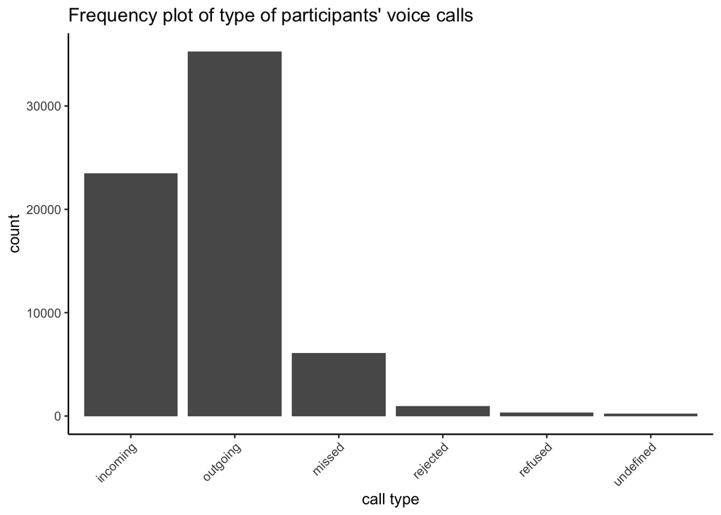

```r
voice %>%
  mutate(call_type = fct_relevel(call_type, c("incoming",
                                              "outgoing",
                                              "missed",
                                              "voicemail",
                                              "rejected",
                                              "refused",
                                              "undefined"))) %>%
  ggplot(aes (x = call_type)) +
  geom_bar() +
  xlab("call type") +
  ggtitle("Frequency plot of type of participants' voice calls") +
  theme_classic() +
  theme(axis.text.x = element_text(angle = 45, hjust = 1))
```

Total number of voice calls per participant

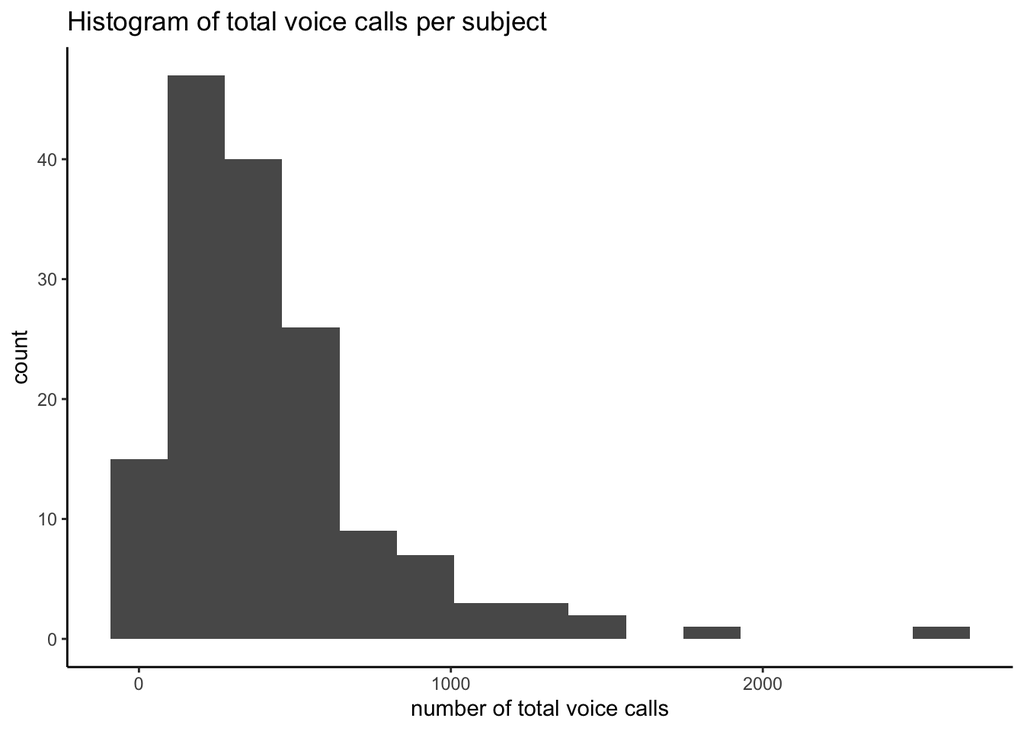

```r
voice %>%
  group_by(subid) %>%
  summarise(n_obs = n()) %>%
  ggplot(aes(x = n_obs)) +
  geom_histogram(bins = 15) +
  xlab("number of total voice calls") +
  ggtitle("Histogram of total voice calls per subject") +
  theme_classic()
```

Average number of calls per day (per participant)

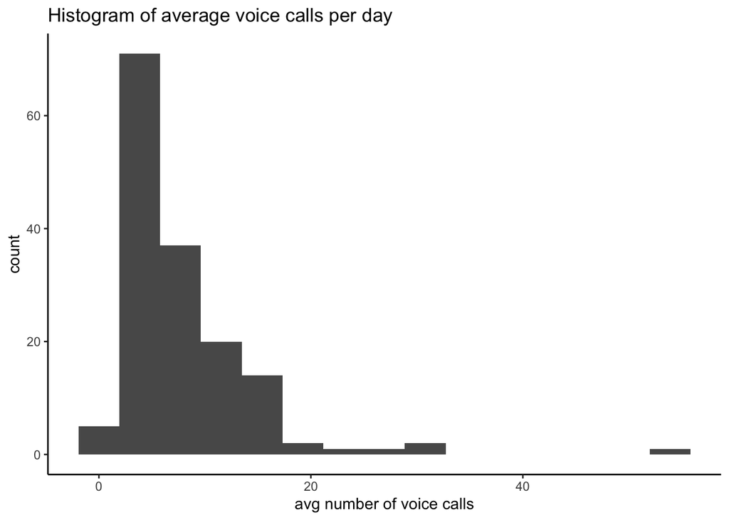

```r
mean_avg_calls_per_day <- voice %>%
  group_by(subid, date_central) %>%
  summarise(n_obs = n()) %>%
  group_by(subid) %>%
  summarise(avg_calls = mean(n_obs)) %>%
  .$avg_calls %>%
  mean()

max_calls_per_day <- voice %>%
  group_by(subid, date_central) %>%
  summarise(n_obs = n()) %>%
  group_by(subid) %>%
  summarise(max = max(n_obs)) %>%
  .$max %>% max()

voice %>%
  group_by(subid, date_central) %>%
  summarise(n_obs = n()) %>%
  group_by(subid) %>%
  summarise(avg_calls_per_day = mean(n_obs)) %>%
  ggplot(aes(x = avg_calls_per_day)) +
  geom_histogram(bins = 15) +
  xlab("avg number of voice calls") +
  ggtitle("Histogram of average voice calls per day") +
  theme_classic()
```

On average, participants had an average of 7.72 voice calls per day (max = 218).

Average number of calls per day (not including spam)

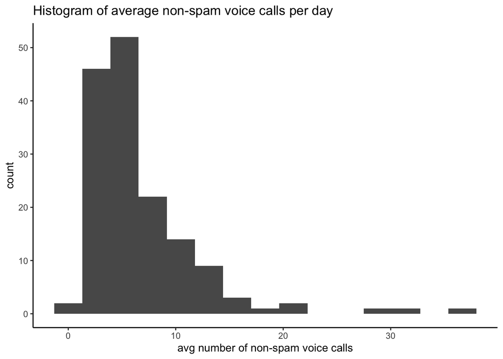

```r
mean_avg_calls_per_day_nospam <- voice_withoutspam %>%
  group_by(subid, date_central) %>%
  summarise(n_obs = n()) %>%
  group_by(subid) %>%
  summarise(avg_calls = mean(n_obs)) %>%
  .$avg_calls %>%
  mean()

max_calls_per_day_nospam <- voice_withoutspam %>%
  group_by(subid, date_central) %>%
  summarise(n_obs = n()) %>%
  group_by(subid) %>%
  summarise(max = max(n_obs)) %>%
  .$max %>% max()

voice_withoutspam %>%
  group_by(subid, date_central) %>%
  summarise(n_obs = n()) %>%
  group_by(subid) %>%
  summarise(avg_calls_per_day = mean(n_obs)) %>%
  ggplot(aes(x = avg_calls_per_day)) +
  geom_histogram(bins = 15) +
  xlab("avg number of non-spam voice calls") +
  ggtitle("Histogram of average non-spam voice calls per day") +
  theme_classic()
```

With spam calls removed, participants had an average of 6.65 voice calls per day (max = 146).

Average number of incoming calls per day

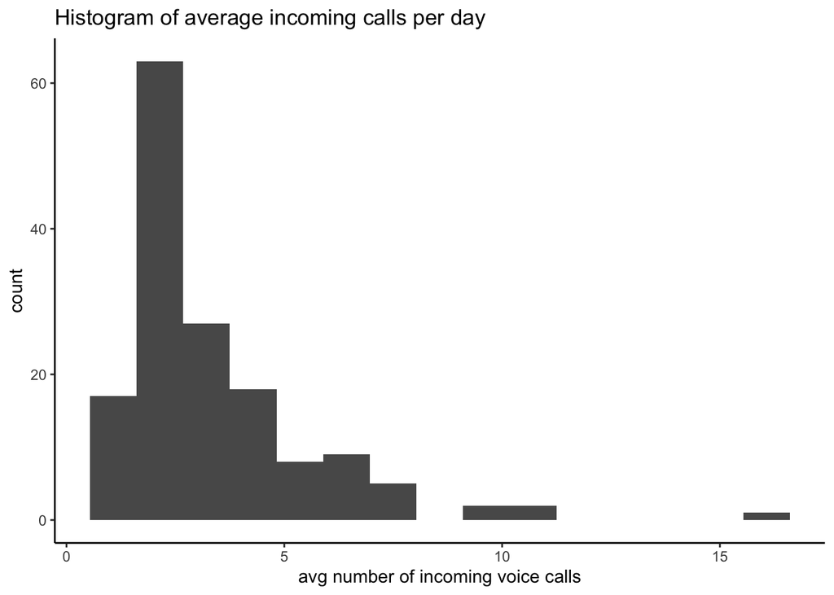

```r
voice %>%
  group_by(subid, date_central) %>%
  filter(type == "1") %>%
  summarise(n_obs = n()) %>%
  group_by(subid) %>%
  summarise(avg_calls_per_day = mean(n_obs)) %>%
  ggplot(aes(x = avg_calls_per_day)) +
  geom_histogram(bins = 15) +
  xlab("avg number of incoming voice calls") +
  ggtitle("Histogram of average incoming calls per day") +
  theme_classic()
```

Average number of outgoing calls per day

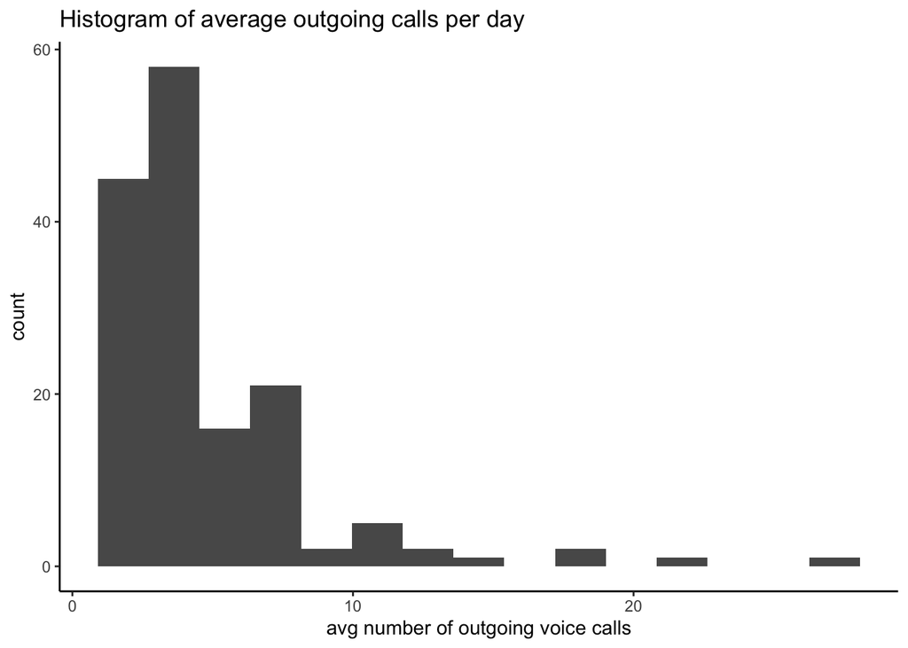

```r
voice %>%
  group_by(subid, date_central) %>%
  filter(type == "2") %>%
  summarise(n_obs = n()) %>%
  group_by(subid) %>%
  summarise(avg_calls_per_day = mean(n_obs)) %>%
  ggplot(aes(x = avg_calls_per_day)) +
  geom_histogram(bins = 15) +
  xlab("avg number of outgoing voice calls") +
  ggtitle("Histogram of average outgoing calls per day") +
  theme_classic()
```

Length of call (in seconds)

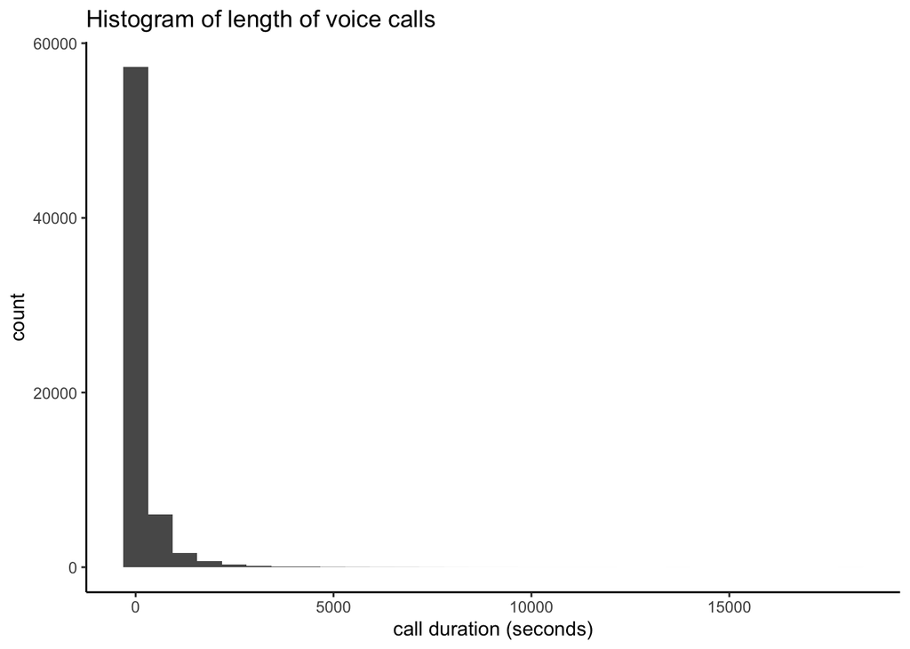

```r
voice %>%
  ggplot(aes(x = duration)) +
  geom_histogram() +
  xlab("call duration (seconds)") +
  ggtitle("Histogram of length of voice calls") +
  theme_classic()
```

Calls with duration of 0 seconds

```r
duration_0 <- voice %>%
  filter(duration == 0)
```

19204 calls (28.93%) had a duration of 0 seconds.

Contact relationship type

```r
voice %>%
  mutate(contact_type = tolower(contact_type),
         contact_type = fct_infreq(factor(contact_type))) %>%
  tabyl(contact_type, show_na = TRUE) %>%
  adorn_totals("row") %>%
  kable(caption = "Relationship with voice call contact") %>%
  kable_styling(full_width = FALSE, position = "left")
```

Relationship with voice call contact

| contact_type | n | percent | valid_percent |
| --- | --- | --- | --- |
| friend | 11714 | 0.1764608 | 0.2302506 |
| spouse/significant other | 10482 | 0.1579019 | 0.2060344 |
| irrelevant/spam | 9452 | 0.1423859 | 0.1857887 |
| parent | 5934 | 0.0893904 | 0.1166388 |
| child | 3253 | 0.0490035 | 0.0639410 |
| co-worker/business contact | 2310 | 0.0347981 | 0.0454054 |
| sibling | 2110 | 0.0317852 | 0.0414742 |
| other | 1942 | 0.0292545 | 0.0381720 |
| self | 1172 | 0.0176551 | 0.0230369 |
| family-other | 1018 | 0.0153353 | 0.0200098 |
| aunt/uncle | 402 | 0.0060558 | 0.0079017 |
| cousin | 384 | 0.0057846 | 0.0075479 |
| counselor | 307 | 0.0046247 | 0.0060344 |
| social worker/case manager | 253 | 0.0038112 | 0.0049730 |
| grandparent | 142 | 0.0021391 | 0.0027912 |
| NA | 15508 | 0.2336140 | NA |
| Total | 66383 | 1.0000000 | 1.0000000 |

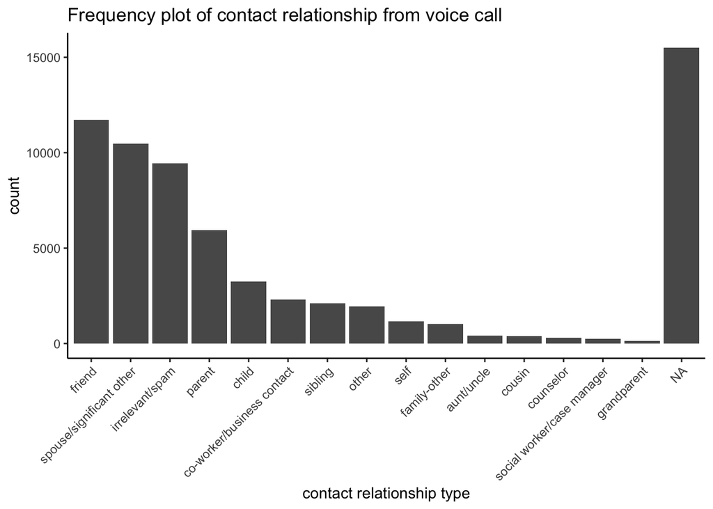

```r
voice %>%
  mutate(contact_type = tolower(contact_type),
         contact_type = fct_infreq(factor(contact_type))) %>%
  ggplot(aes (x = contact_type)) +
  geom_bar() +
  xlab("contact relationship type") +
  ggtitle("Frequency plot of contact relationship from voice call") +
  theme_classic() +
  theme(axis.text.x = element_text(angle = 45, hjust = 1))
```

15508 voice calls (23.36%) were from unknown contacts.

Number of calls from known contacts per participant

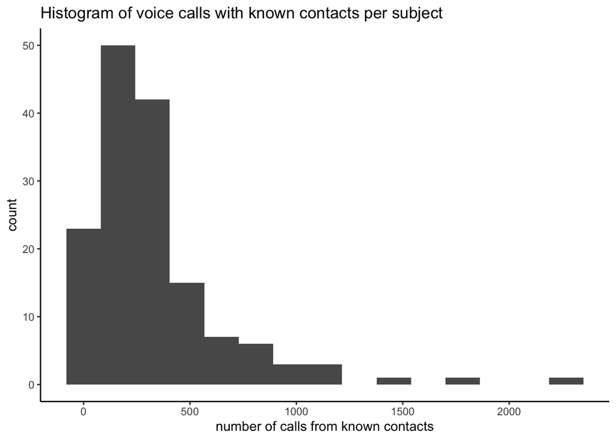

```r
voice %>%
  filter(!is.na(contact_type)) %>%
  group_by(subid) %>%
  summarise(n_obs = n()) %>%
  ggplot(aes(x = n_obs)) +
  geom_histogram(bins = 15) +
  xlab("number of calls from known contacts") +
  ggtitle("Histogram of voice calls with known contacts per subject") +
  theme_classic()
```

Number of calls from unknown contacts per participant (contact_type = NA)

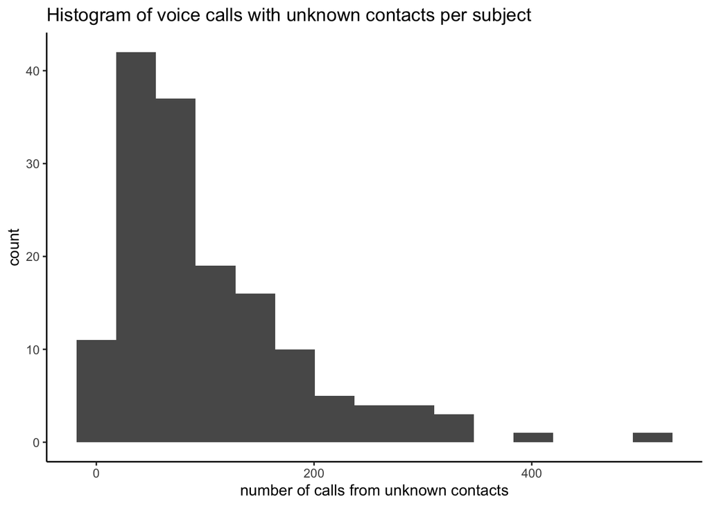

```r
voice %>%
  filter(is.na(contact_type)) %>%
  group_by(subid) %>%
  summarise(n_obs = n()) %>%
  ggplot(aes(x = n_obs)) +
  geom_histogram(bins = 15) +
  xlab("number of calls from unknown contacts") +
  ggtitle("Histogram of voice calls with unknown contacts per subject") +
  theme_classic()
```

Number of calls from spam

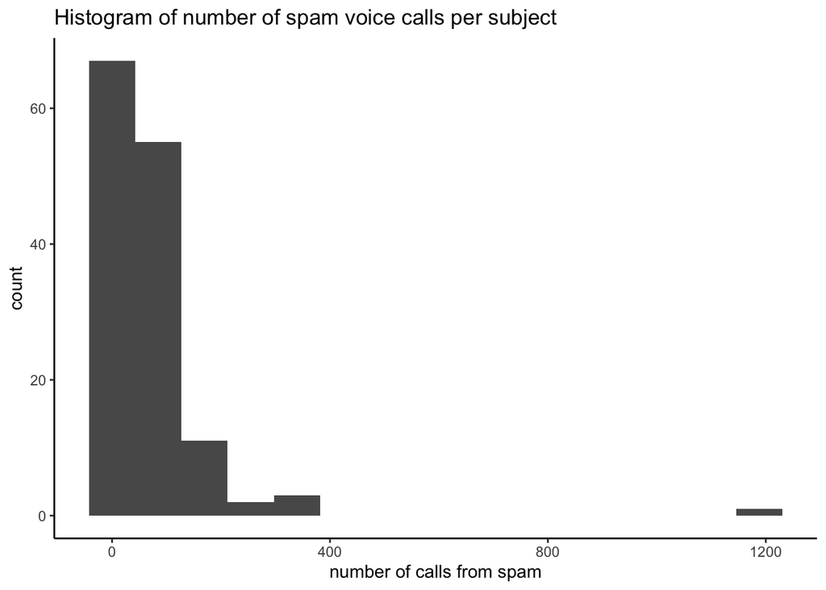

```r
voice %>%
  filter(contact_type == "IRRELEVANT/SPAM") %>%
  group_by(subid) %>%
  summarise(n_obs = n()) %>%
  ggplot(aes(x = n_obs)) +
  geom_histogram(bins = 15) +
  xlab("number of calls from spam") +
  ggtitle("Histogram of number of spam voice calls per subject") +
  theme_classic()
```

Average call length by contact type

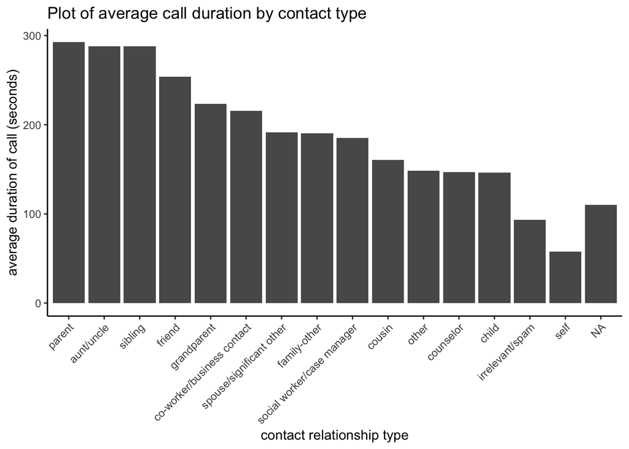

```r
voice %>%
  mutate(contact_type = tolower(contact_type),
         contact_type = fct_reorder(contact_type, desc(duration), .fun = "mean")) %>%
  group_by(contact_type) %>%
  summarise(avg_duration = mean(duration)) %>%
  ggplot(aes (x = contact_type, y = avg_duration)) +
  geom_col() +
  xlab("contact relationship type") +
  ylab("average duration of call (seconds)") +
  ggtitle("Plot of average call duration by contact type") +
  theme_classic() +
  theme(axis.text.x = element_text(angle = 45, hjust = 1))
```

Average number of contacts per participant

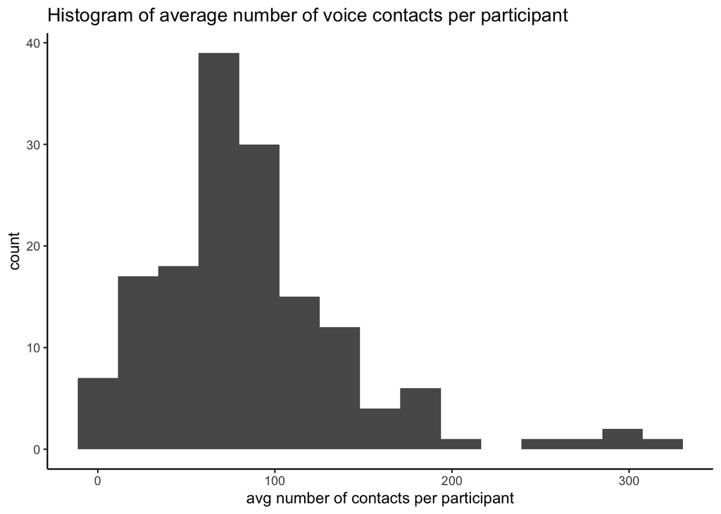

```r
voice %>%
  group_by(subid) %>%
  mutate(n_contacts = n_distinct(phone))  %>%
  summarise(avg_contacts_per_sub = mean(n_contacts)) %>%
  ggplot(aes(x = avg_contacts_per_sub)) +
  geom_histogram(bins = 15) +
  xlab("avg number of contacts per participant") +
  ggtitle("Histogram of average number of voice contacts per participant") +
  theme_classic()
```

Average number of contacts per day (per participant)

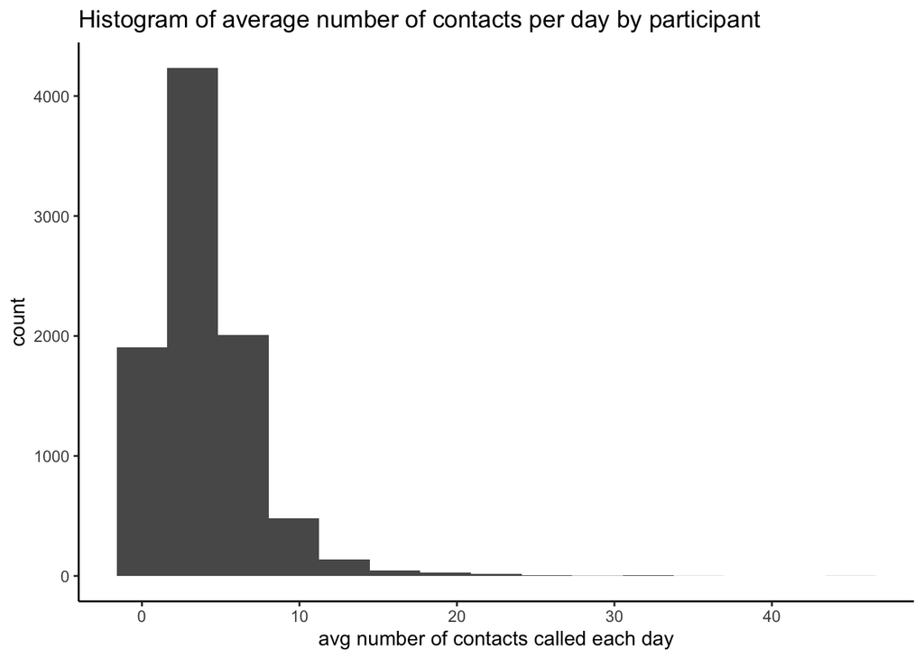

```r
voice %>%
  group_by(subid, date_central) %>%
  mutate(n_contacts = n_distinct(phone))  %>%
  summarise(avg_contacts_perday = mean(n_contacts)) %>%
  ggplot(aes(x = avg_contacts_perday)) +
  geom_histogram(bins = 15) +
  xlab("avg number of contacts called each day") +
  ggtitle("Histogram of average number of contacts per day by participant") +
  theme_classic()
```

#### Context variables

Context analyses are run on dataframe with spam/irrelevant calls removed because these calls have no context information.

Drank alcohol in past

```r
voice_withoutspam %>%
  mutate(drank_past = tolower(drank_past),
         drank_past = fct_relevel(factor(drank_past, c("never/almost never", "occasionally",
                                                        "almost always/always")))) %>%
  tabyl(drank_past, show_na = TRUE) %>%
  adorn_totals("row") %>%
  kable(caption = "Level of drinking with voice contact in the past") %>%
  kable_styling(full_width = FALSE, position = "left")
```

Level of drinking with voice contact in the past

| drank_past | n | percent | valid_percent |
| --- | --- | --- | --- |
| never/almost never | 18623 | 0.3271153 | 0.4639281 |
| occasionally | 15334 | 0.2693436 | 0.3819939 |
| almost always/always | 6185 | 0.1086403 | 0.1540780 |
| NA | 16789 | 0.2949008 | NA |
| Total | 56931 | 1.0000000 | 1.0000000 |

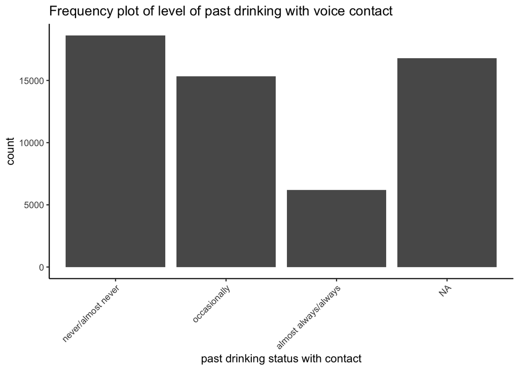

```r
voice_withoutspam %>%
  mutate(drank_past = tolower(drank_past),
         drank_past = fct_relevel(factor(drank_past, c("never/almost never", "occasionally",
                                                        "almost always/always")))) %>%
  ggplot(aes (x = drank_past)) +
  geom_bar() +
  xlab("past drinking status with contact") +
  ggtitle("Frequency plot of level of past drinking with voice contact") +
  theme_classic() +
  theme(axis.text.x = element_text(angle = 45, hjust = 1))
```

Drinker status

```r
voice_withoutspam %>%
  mutate(drinker_status = tolower(drinker_status),
         drinker_status = fct_relevel(factor(drinker_status, c("drinker", "nondrinker",
                                                        "dont know")))) %>%
  tabyl(drinker_status, show_na = TRUE) %>%
  adorn_totals("row") %>%
  kable(caption = "Drinking status of voice contact") %>%
  kable_styling(full_width = FALSE, position = "left")
```

Drinking status of voice contact

| drinker_status | n | percent | valid_percent |
| --- | --- | --- | --- |
| drinker | 23348 | 0.4101105 | 0.5813021 |
| nondrinker | 12673 | 0.2226028 | 0.3155235 |
| dont know | 4144 | 0.0727899 | 0.1031744 |
| NA | 16766 | 0.2944968 | NA |
| Total | 56931 | 1.0000000 | 1.0000000 |

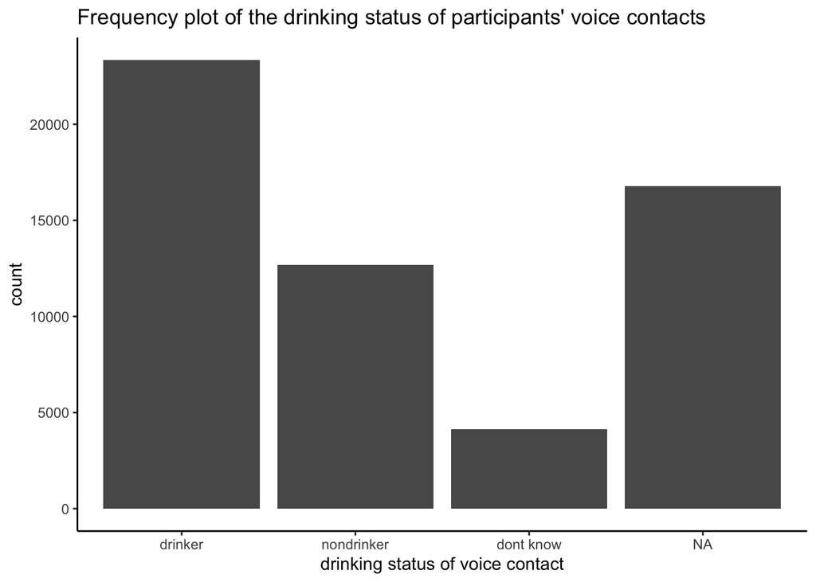

```r
voice_withoutspam %>%
  mutate(drinker_status = tolower(drinker_status),
         drinker_status = fct_relevel(factor(drinker_status, c("drinker", "nondrinker",
                                                        "dont know")))) %>%
  ggplot(aes (x = drinker_status)) +
  geom_bar() +
  xlab("drinking status of voice contact") +
  ggtitle("Frequency plot of the drinking status of participants' voice contacts") +
  theme_classic()
```

Drink in your presence

```r
voice_withoutspam %>%
  mutate(drink_future = tolower(drink_future),
         drink_future = fct_relevel(factor(drink_future, c("yes", "no",
                                                        "uncerain")))) %>%
  tabyl(drink_future, show_na = TRUE) %>%
  adorn_totals("row") %>%
  kable(caption = "Is voice contact likely to drink in your presence?") %>%
  kable_styling(full_width = FALSE, position = "left")
```

Is voice contact likely to drink in your presence?

| drink_future | n | percent | valid_percent |
| --- | --- | --- | --- |
| yes | 13506 | 0.2372345 | 0.38807 |
| no | 21297 | 0.3740844 | 0.61193 |
| uncerain | 0 | 0.0000000 | 0.00000 |
| NA | 22128 | 0.3886810 | NA |
| Total | 56931 | 1.0000000 | 1.00000 |

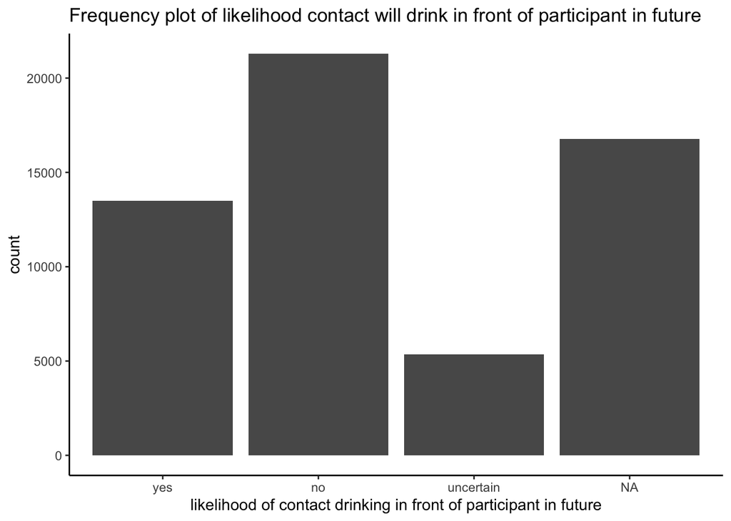

```r
voice_withoutspam %>%
  mutate(drink_future = tolower(drink_future),
         drink_future = fct_relevel(factor(drink_future, c("yes", "no",
                                                        "uncertain")))) %>%
  ggplot(aes (x = drink_future)) +
  geom_bar() +
  xlab("likelihood of contact drinking in front of participant in future") +
  ggtitle("Frequency plot of likelihood contact will drink in front of participant in future") +
  theme_classic()
```

In recovery

```r
voice_withoutspam %>%
  mutate(recovery = tolower(recovery),
         recovery = fct_relevel(factor(recovery, c("yes", "no",
                                                        "dont know")))) %>%
  tabyl(recovery, show_na = TRUE) %>%
  adorn_totals("row") %>%
  kable(caption = "Is voice contact in recovery?") %>%
  kable_styling(full_width = FALSE, position = "left")
```

Is voice contact in recovery?

| recovery | n | percent | valid_percent |
| --- | --- | --- | --- |
| yes | 7244 | 0.1272417 | 0.1805808 |
| no | 28830 | 0.5064025 | 0.7186838 |
| dont know | 4041 | 0.0709807 | 0.1007354 |
| NA | 16816 | 0.2953751 | NA |
| Total | 56931 | 1.0000000 | 1.0000000 |

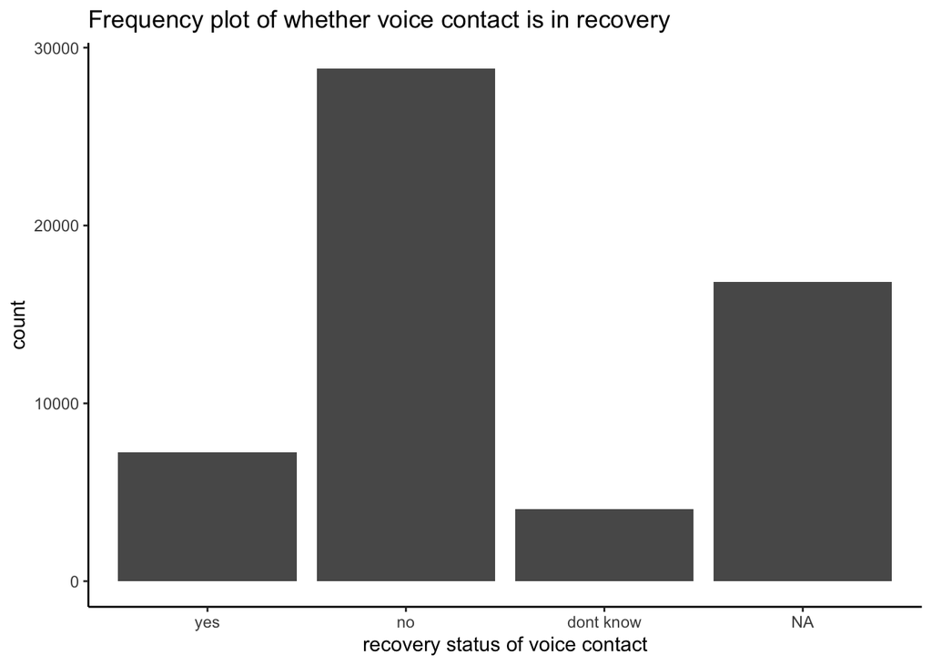

```r
voice_withoutspam %>%
  mutate(recovery = tolower(recovery),
         recovery = fct_relevel(factor(recovery, c("yes", "no",
                                                        "dont know")))) %>%
  ggplot(aes (x = recovery)) +
  geom_bar() +
  xlab("recovery status of voice contact") +
  ggtitle("Frequency plot of whether voice contact is in recovery") +
  theme_classic()
```

Support of recovery

```r
voice_withoutspam %>%
  mutate(support = tolower(support),
         support = fct_relevel(factor(support, c("supportive", "unsupportive", "mixed",
                                                 "neutral", "dont know", "no")))) %>%
  tabyl(support, show_na = TRUE) %>%
  adorn_totals("row") %>%
  kable(caption = "Contact's support of participant's recovery goals") %>%
  kable_styling(full_width = FALSE, position = "left")
```

Contact’s support of participant’s recovery goals

| support | n | percent | valid_percent |
| --- | --- | --- | --- |
| supportive | 30795 | 0.5409180 | 0.7668078 |
| unsupportive | 574 | 0.0100824 | 0.0142928 |
| mixed | 2275 | 0.0399607 | 0.0566484 |
| neutral | 520 | 0.0091339 | 0.0129482 |
| dont know | 5996 | 0.1053205 | 0.1493028 |
| no | 0 | 0.0000000 | 0.0000000 |
| NA | 16771 | 0.2945847 | NA |
| Total | 56931 | 1.0000000 | 1.0000000 |

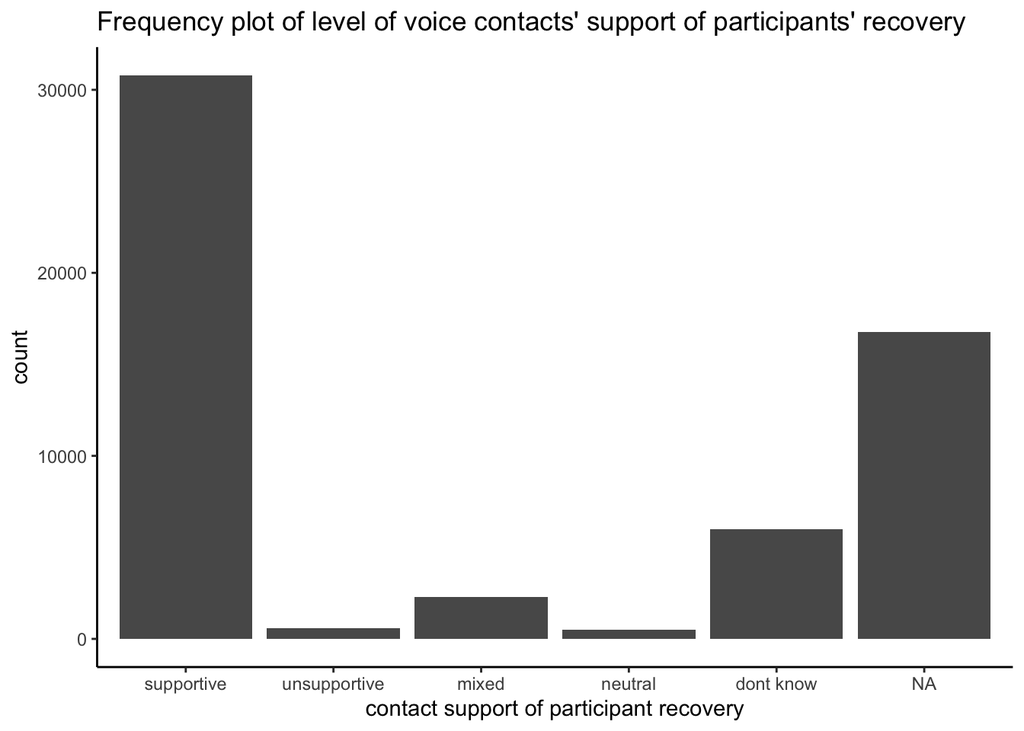

```r
voice_withoutspam %>%
  mutate(support = tolower(support),
         support = fct_relevel(factor(support, c("supportive", "unsupportive", "mixed",
                                                 "neutral", "dont know", "no")))) %>%
  ggplot(aes (x = support)) +
  geom_bar() +
  xlab("contact support of participant recovery") +
  ggtitle("Frequency plot of level of voice contacts' support of participants' recovery") +
  theme_classic()
```

Emotion from experiences with contact

```r
voice_withoutspam %>%
  mutate(emotion = tolower(emotion),
         emotion = fct_relevel(factor(emotion, c("pleasant", "unpleasant",
                                                 "mixed", "neutral")))) %>%
  tabyl(emotion, show_na = TRUE) %>%
  adorn_totals("row") %>%
  kable(caption = "Emotion from experiences with voice contact") %>%
  kable_styling(full_width = FALSE, position = "left")
```

Emotion from experiences with voice contact

| emotion | n | percent | valid_percent |
| --- | --- | --- | --- |
| pleasant | 27831 | 0.4888549 | 0.6933483 |
| unpleasant | 830 | 0.0145791 | 0.0206776 |
| mixed | 10609 | 0.1863484 | 0.2643000 |
| neutral | 870 | 0.0152817 | 0.0216741 |
| NA | 16791 | 0.2949360 | NA |
| Total | 56931 | 1.0000000 | 1.0000000 |

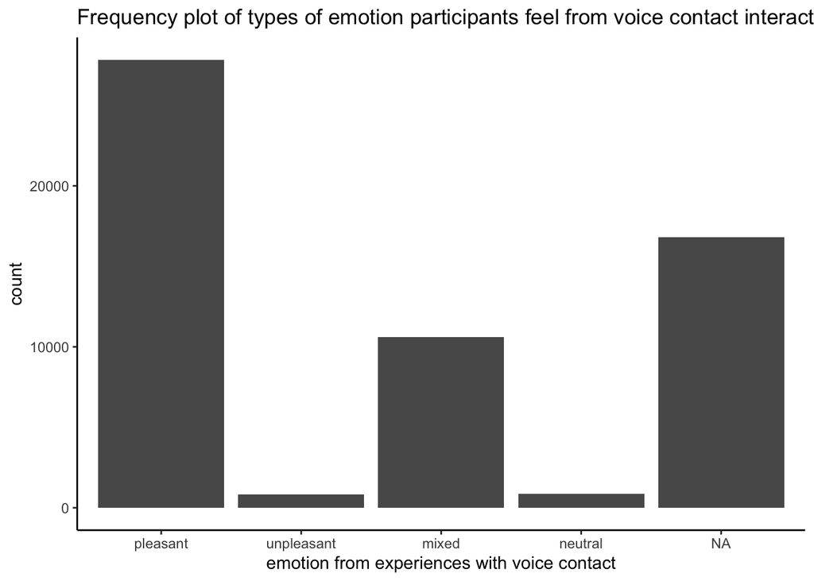

```r
voice_withoutspam %>%
  mutate(emotion = tolower(emotion),
         emotion = fct_relevel(factor(emotion, c("pleasant", "unpleasant",
                                                 "mixed", "neutral")))) %>%
  ggplot(aes (x = emotion)) +
  geom_bar() +
  xlab("emotion from experiences with voice contact") +
  ggtitle("Frequency plot of types of emotion participants feel from voice contact interactions") +
  theme_classic()
```